# Çok Değişkenli Çözümleme Dönem Ödevi

Mehmet Şenel

2024-11-30

## Soru 1

Verilen matrislerin pozitif tanımlı olup olmadığını belirleyiniz:

- **A**
  $$\begin{bmatrix}
  5 & -4 & 3 \\
  4 & 3 & 2 \\
  3 & 2 & 2 \\
  \end{bmatrix}$$
- **B**
  $$\begin{bmatrix}
  4 & -3 & 1 \\
  -3 & 4 & 2 \\
  1 & 2 & 3 \\
  \end{bmatrix}$$
- **C**
  $$\begin{bmatrix}
  3 & 2 & 1 \\
  2 & 6 & 3 \\
  1 & 3 & 1 \\
  \end{bmatrix}$$
- **D**
  $$\begin{bmatrix}
  3 & 3 & 1 \\
  3 & 4 & 2 \\
  1 & 2 & 2 \\
  \end{bmatrix}$$

## Çözüm 1

### Pozitif Tanımlılık Nedir?

Bir matrisin pozitif tanımlı olabilmesi için:

1. **Simetrik** olması gerekir.
2. **Tüm özdeğerlerinin pozitif olması** gerekir.

Bu kriterlerden biri sağlanmazsa, matris pozitif tanımlı değildir.

#### Matrislerin Tanımlanması

```r
# Matrislerin tanımlanması
A <- matrix(c(5, -4, 3,
              4, 3, 2,
              3, 2, 2), nrow = 3, byrow = TRUE)

B <- matrix(c(4, -3, 1,
              -3, 4, 2,
              1, 2, 3), nrow = 3, byrow = TRUE)

C <- matrix(c(3, 2, 1,
              2, 6, 3,
              1, 3, 1), nrow = 3, byrow = TRUE)

D <- matrix(c(3, 3, 1,
              3, 4, 2,
              1, 2, 2), nrow = 3, byrow = TRUE)
```

#### Özdeğer Kontrolü

```r
# Pozitif tanımlılığı kontrol eden fonksiyon (özdeğer yöntemi)
is_positive_definite <- function(mat) {
  eigenvalues <- eigen(mat)$values
  all(Re(eigenvalues) > 0) # Sadece gerçek kısmını kontrol et
}
```

- Oluşturulan fonksiyona istinaden matrisler sırasıyla kontrol edilir, çıkan cevap “False” ise matrisin pozitif tanımlı olmadığı , çıkan cevap “True” ise matrisin pozitif tanımlı olduğu anlaşılmaktadır.

#### Matrislerin kontrolü

```r
# Sonuçları bir tabloya dökme
results <- data.frame(
  Matris = c("A", "B", "C", "D"),
  Pozitif_Tanimli = c(
    is_positive_definite(A),
    is_positive_definite(B),
    is_positive_definite(C),
    is_positive_definite(D)
  )
)

# Tablo formatında sonuçları göster
knitr::kable(results, caption = "Matrislerin Pozitif Tanımlılık Sonuçları")
```

Matrislerin Pozitif Tanımlılık Sonuçları

| Matris | Pozitif_Tanimli |
| --- | --- |
| A | TRUE |
| B | FALSE |
| C | FALSE |
| D | TRUE |

## Soru 2

Verilen yoğunluk fonksiyonu:

$$f(x) = k e^{-\frac{1}{2} Q}$$

Burada $Q$ fonksiyonu şu şekilde verilmiştir:

$$Q = x_1^2 + 5x_2^2 + 2x_3^2 + 6x_2x_3 - 4x_1 - 8x_2 - 6x_3 + 9$$

Yoğunluk fonksiyonunun yayılım parametresi ve ortalama vektörünü hesaplayınız. En yüksek yayılıma ve en düşük ortalamaya sahip olan değişkenleri belirleyiniz.

## Çözüm 2

### 1. $Q$ Fonksiyonunun Temsili

Verilen $Q$ fonksiyonu şu şekilde verilmiştir:

$$Q = x_1^2 + 5x_2^2 + 2x_3^2 + 6x_2x_3 - 4x_1 - 8x_2 - 6x_3 + 9$$

$$f(x) = k \cdot e^{-\frac{1}{2} Q}$$

### Q fonksiyonu için matris ve vektör temsili

```r
knitr::opts_chunk$set(echo = TRUE)
A <- matrix(c(1, 0, 0,
              0, 5, 3,
              0, 3, 2), nrow = 3, byrow = TRUE)  # Kovaryans matrisi
b <- c(-4, -8, -6)  # Lineer terimler
c <- 9  # Sabit terim
```

### Ortalama Vektörü Hesaplama

```r
# Ortalama vektörü
mu <- solve(A) %*% (-b / 2)
mu  # Ortalama vektörü
```

```
##      [,1]
## [1,]    2
## [2,]   -1
## [3,]    3
```

### Kovaryans Matrisi ve Varyanslar

```r
# Yayılım matrisi (Kovaryans matrisi)
cov_matrix <- solve(A)

# Varyanslar (Kovaryans matrisinin köşegen elemanları)
variances <- diag(cov_matrix)
variances  # Varyanslar
```

```
## [1] 1 2 5
```

### En Yüksek Varyans ve En Düşük Ortalama

```r
# En yüksek varyans ve en düşük ortalama
max_variance <- max(variances)
max_var_index <- which(variances == max_variance)
cat("En yüksek yayılıma sahip değişken: x", max_var_index, "\n")
```

```
## En yüksek yayılıma sahip değişken: x 3
```

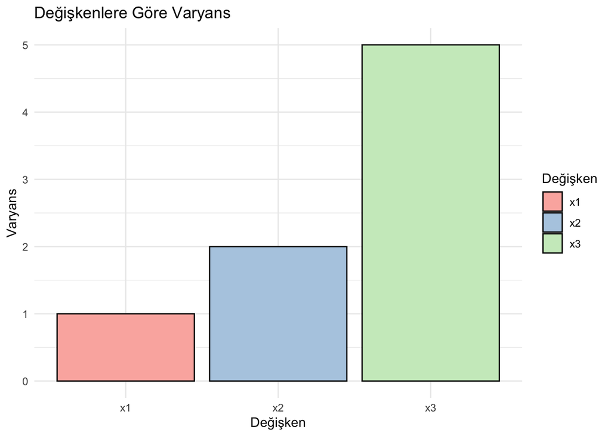

- **Yukarıda çıktıda ve özellikle grafikte açıkca görüldüğü üzere “X3” değişkeni en çok yayılıma sahip değişkendir.**

```r
min_mean <- min(mu)
min_mean_index <- which(mu == min_mean)
cat("En düşük ortalamaya sahip değişken: x", min_mean_index, "\n")
```

```
## En düşük ortalamaya sahip değişken: x 2
```

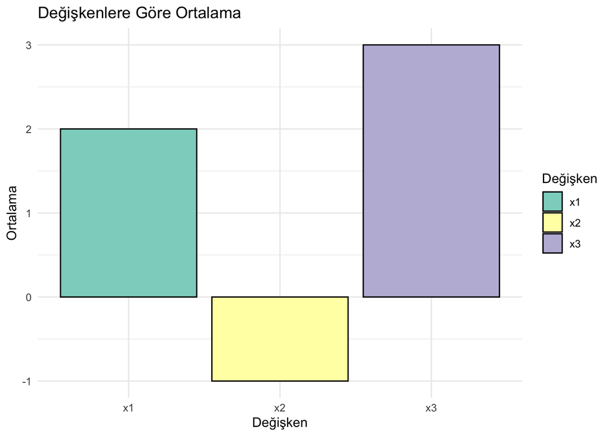

## Çözüm

Bu soruyu çözmek için ANOVA (Varyans Analizi) testi kullanacağız. Verimizdeki her bir değişken için (Bitki Boyu, Yaprak Alanı, Biyokütle) gruplar arasındaki farkı test edeceğiz. Ayrıca, verilerin normal dağılım gösterip göstermediğini kontrol etmek için **Shapiro-Wilk testi** ve **Histogram Grafikleri**, varyansların eşitliğini test etmek için ise **Levene testi** uygulanacaktır.

### 1. Veriyi Yükleme

Veriyi **`read_excel`** fonksiyonu ile yükleyeceğiz ve veri setini inceleyeceğiz.

```r
# Gerekli paketleri yükleyelim
library(readxl)

# Dosya yolunu belirtelim
gubre_1_ <- read_excel("/Users/mehmetsenel/Desktop/gubre (1).xlsx")

# İlk birkaç satırı görüntüleyelim ve estetik formatla gösterelim
library(knitr)
kable(head(gubre_1_), caption = "İlk 6 Satır - Gübre Verisi", format = "html", align = "c")
```

İlk 6 Satır - Gübre Verisi

| Grup | Bitki Boyu (cm) | Yaprak Alanı (cm²) | Biyokütle (g) |
| --- | --- | --- | --- |
| Organik | 45.3 | 200.5 | 15.8 |
| Organik | 44.9 | 198.7 | 15.5 |
| Organik | 46.0 | 202.1 | 16.0 |
| Organik | 45.7 | 201.3 | 15.9 |
| Organik | 44.8 | 198.0 | 15.6 |
| Organik | 46.2 | 202.5 | 16.1 |

### 2. Görselleştirme ve Normal Dağılım Testi (Shapiro-Wilk)

```r
# Shapiro-Wilk testi ile normal dağılım kontrolü
shapiro_test_boyu <- shapiro.test(gubre_1_$`Bitki Boyu (cm)`)
shapiro_test_yaprak <- shapiro.test(gubre_1_$`Yaprak Alanı (cm²)`)
shapiro_test_biyokutle <- shapiro.test(gubre_1_$`Biyokütle (g)`)
```

```r
shapiro_test_boyu
```

```
##
##  Shapiro-Wilk normality test
##
## data:  gubre_1_$`Bitki Boyu (cm)`
## W = 0.7533, p-value = 2.583e-07
```

```r
shapiro_test_yaprak
```

```
##
##  Shapiro-Wilk normality test
##
## data:  gubre_1_$`Yaprak Alanı (cm²)`
## W = 0.73652, p-value = 1.238e-07
```

```r
shapiro_test_biyokutle
```

```
##
##  Shapiro-Wilk normality test
##
## data:  gubre_1_$`Biyokütle (g)`
## W = 0.80896, p-value = 3.765e-06
```

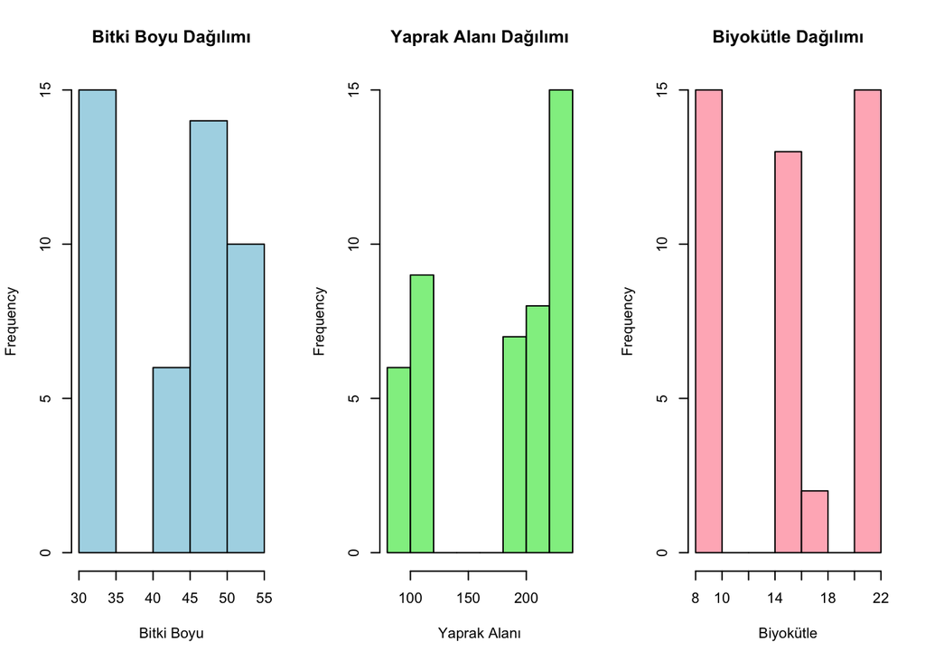

```r
# Histogramlarla normal dağılım kontrolü
par(mfrow = c(1, 3))
hist(gubre_1_$`Bitki Boyu (cm)`, main = "Bitki Boyu Dağılımı", xlab = "Bitki Boyu", col = "lightblue")
hist(gubre_1_$`Yaprak Alanı (cm²)`, main = "Yaprak Alanı Dağılımı", xlab = "Yaprak Alanı", col = "lightgreen")
hist(gubre_1_$`Biyokütle (g)`, main = "Biyokütle Dağılımı", xlab = "Biyokütle", col = "lightpink")
```

### 3. Varyans homojenliği kontrolü

```r
# Levene testi
library(car)
leveneTest(`Bitki Boyu (cm)` ~ Grup, data = gubre_1_)
```

```
## Levene's Test for Homogeneity of Variance (center = median)
##       Df F value    Pr(>F)
## group  2  13.199 3.568e-05 ***
##       42
## ---
## Signif. codes:  0 '***' 0.001 '**' 0.01 '*' 0.05 '.' 0.1 ' ' 1
```

```r
leveneTest(`Yaprak Alanı (cm²)` ~ Grup, data = gubre_1_)
```

```
## Levene's Test for Homogeneity of Variance (center = median)
##       Df F value    Pr(>F)
## group  2  9.3212 0.0004466 ***
##       42
## ---
## Signif. codes:  0 '***' 0.001 '**' 0.01 '*' 0.05 '.' 0.1 ' ' 1
```

```r
leveneTest(`Biyokütle (g)` ~ Grup, data = gubre_1_)
```

```
## Levene's Test for Homogeneity of Variance (center = median)
##       Df F value  Pr(>F)
## group  2  2.9256 0.06464 .
##       42
## ---
## Signif. codes:  0 '***' 0.001 '**' 0.01 '*' 0.05 '.' 0.1 ' ' 1
```

### 4. ANOVA Testi

```r
# ANOVA testleri
anova_boyu <- aov(`Bitki Boyu (cm)` ~ Grup, data = gubre_1_)
anova_yaprak <- aov(`Yaprak Alanı (cm²)` ~ Grup, data = gubre_1_)
anova_biyokutle <- aov(`Biyokütle (g)` ~ Grup, data = gubre_1_)
```

```r
# Sonuçları görüntüleme
summary(anova_boyu)
```

```
##             Df Sum Sq Mean Sq F value Pr(>F)
## Grup         2 3155.2  1577.6    9846 <2e-16 ***
## Residuals   42    6.7     0.2
## ---
## Signif. codes:  0 '***' 0.001 '**' 0.01 '*' 0.05 '.' 0.1 ' ' 1
```

```r
summary(anova_yaprak)
```

```
##             Df Sum Sq Mean Sq F value Pr(>F)
## Grup         2 138430   69215   36221 <2e-16 ***
## Residuals   42     80       2
## ---
## Signif. codes:  0 '***' 0.001 '**' 0.01 '*' 0.05 '.' 0.1 ' ' 1
```

```r
summary(anova_biyokutle)
```

```
##             Df Sum Sq Mean Sq F value Pr(>F)
## Grup         2 1145.5   572.8   12778 <2e-16 ***
## Residuals   42    1.9     0.0
## ---
## Signif. codes:  0 '***' 0.001 '**' 0.01 '*' 0.05 '.' 0.1 ' ' 1
```

### Sonuç:

- p-değeriniz 0.05’ten küçükse, ANOVA testi ile gruplar arasında anlamlı bir fark bulunduğunu ve gübre türlerinin bitki boyu, yaprak alanı veya biyokütle üzerinde farklı etkiler yaratabileceğini söyleyebiliriz.
- İleri Adım: Eğer fark varsa, hangi gruplar arasında fark olduğunu görmek için post-hoc testleri (örneğin Tukey HSD testi) uygulayabiliriz.

```r
# Tukey HSD testi
tukey_boyu <- TukeyHSD(anova_boyu)
tukey_yaprak <- TukeyHSD(anova_yaprak)
tukey_biyokutle <- TukeyHSD(anova_biyokutle)
```

```r
# Sonuçları görüntüleme
print(tukey_boyu)
```

```
##   Tukey multiple comparisons of means
##     95% family-wise confidence level
##
## Fit: aov(formula = `Bitki Boyu (cm)` ~ Grup, data = gubre_1_)
##
## $Grup
##                        diff        lwr       upr p adj
## Kontrol-Kimyasal -19.660000 -20.015097 -19.30490     0
## Organik-Kimyasal  -4.766667  -5.121763  -4.41157     0
## Organik-Kontrol   14.893333  14.538237  15.24843     0
```

```r
print(tukey_yaprak)
```

```
##   Tukey multiple comparisons of means
##     95% family-wise confidence level
##
## Fit: aov(formula = `Yaprak Alanı (cm²)` ~ Grup, data = gubre_1_)
##
## $Grup
##                        diff        lwr        upr p adj
## Kontrol-Kimyasal -129.64000 -130.86633 -128.41367     0
## Organik-Kimyasal  -29.63333  -30.85966  -28.40701     0
## Organik-Kontrol   100.00667   98.78034  101.23299     0
```

```r
print(tukey_biyokutle)
```

```
##   Tukey multiple comparisons of means
##     95% family-wise confidence level
##
## Fit: aov(formula = `Biyokütle (g)` ~ Grup, data = gubre_1_)
##
## $Grup
##                        diff        lwr        upr p adj
## Kontrol-Kimyasal -12.280000 -12.467822 -12.092178     0
## Organik-Kimyasal  -4.933333  -5.121156  -4.745511     0
## Organik-Kontrol    7.346667   7.158844   7.534489     0
```

### Sonuç Yorumu:

- Kimyasal gübre tüm ölçülen parametrelerde (bitki boyu, yaprak alanı, biyokütle) kontrol grubuna kıyasla anlamlı şekilde daha iyi performans göstermektedir.
- Organik gübre, kimyasal gübreye kıyasla bitki boyu, yaprak alanı ve biyokütle ölçümlerinde daha düşük sonuçlar elde etmiştir, ancak kontrol grubuna kıyasla her üç ölçümde de anlamlı farklar bulunmuştur.
- Sonuçlar, kimyasal gübrenin bitki gelişimi üzerinde en iyi etkiye sahip olduğunu göstermektedir, ancak organik gübre de kontrol grubuna göre belirgin bir iyileşme sağlamaktadır.

Bu sonuçlar, kimyasal gübrenin bitki büyümesi üzerinde daha güçlü bir etki yaptığını ve organik gübrenin de etkili bir seçenek olabileceğini ortaya koymaktadır.

## Soru 4

Bir tekstil mağazasının yöneticisi, 10 farklı dönemde “klasik mavi” kazak satışlarını incelemiş ve satılan kazak sayısını (X1), fiyat değişimini (X2, Euro cinsinden), yerel gazetelerdeki reklam maliyetlerini (X3, Euro cinsinden) ve satış asistanının varlığını (X4, dönem başına saat olarak) gözlemlemiştir. Dönemler boyunca aşağıdaki veri matrisini kaydetmiş ve fiyat değişimlerinin, satılan kazak sayısı üzerinde büyük bir etkisi olması gerektiğine ikna olmuştur. Sizce mağaza yöneticisi bu görüşünde haklı mıdır? Haklıysa ya da haklı değilse neden? Cevabınızı R programındaki bulgularınızla birlikte destekleyiniz.

X =
$$\begin{bmatrix}
230 & 181 & 165 & 150 & 97 & 192 & 181 & 189
& 172 & 170 \\
125 & 99 & 97 & 115 & 120 & 100 & 80 & 90
& 95 & 125 \\
200 & 55 & 105 & 85 & 0 & 150 & 85 & 120
& 110 & 130 \\
109 & 107 & 98 & 71 & 82 & 103 & 111 & 93
& 86 & 78 \\
\end{bmatrix}$$

## Çözüm 4

- Bu soruyu çözmek için, fiyat değişimi (X2) ile satılan kazak sayısı (X1) arasındaki ilişkiyi inceleyeceğiz. Bunun için **korelasyon analizi** yapacağız.
- Bu soruda sadece X1 ve X2’yi inceleyeceğiz çünkü soruda fiyat değişiminin satılan kazak sayısı üzerindeki etkisini test etmek isteniyor. Diğer değişkenler de satışları etkileyebilir, ancak bu soruda sorulmak istenen soru, yalnızca fiyat değişiminin etkisiyle ilgili olduğu için sadece bu iki değişken incelenecektir. Eğer daha geniş bir analiz yapmamız gerekseydi, tüm değişkenler göz önünde bulundurularak daha karmaşık bir analiz (çok değişkenli regresyon) yapılabilirdi.

```r
# Veriyi tanımlama
X1 <- c(230, 181, 165, 150, 97, 192, 181, 189, 172, 170)
X2 <- c(125, 99, 97, 115, 120, 100, 80, 90, 95, 125)

# Korelasyon hesaplama
korelasyon <- cor(X1, X2)

# Sonucu yazdırma
cat("X1 (Satılan Kazak Sayısı) ile X2 (Fiyat Değişimi) arasındaki korelasyon:", korelasyon, "\n")
```

```
## X1 (Satılan Kazak Sayısı) ile X2 (Fiyat Değişimi) arasındaki korelasyon: -0.167576
```

Korelasyon Katsayısının Yorumlanması Korelasyon katsayısı, -1 ile 1 arasında bir değer alır:

- +1: Mükemmel pozitif ilişki (değişkenler tamamen aynı yönde hareket eder)
- -1: Mükemmel negatif ilişki (değişkenler tam ters yönde hareket eder)
- 0: Hiçbir ilişki yok (değişkenler arasında doğrusal bir ilişki bulunmaz)

```r
# Korelasyon katsayısına göre değerlendirme
if(korelasyon > 1) {
  cat("Fiyat değişimi ile satılan kazak sayısı arasında güçlü bir pozitif ilişki var.\n")
} else if(korelasyon < -1) {
  cat("Fiyat değişimi ile satılan kazak sayısı arasında güçlü bir negatif ilişki var.\n")
} else {
  cat("Fiyat değişimi ile satılan kazak sayısı arasında zayıf veya hiçbir ilişki yok.\n")
}
```

```
## Fiyat değişimi ile satılan kazak sayısı arasında zayıf veya hiçbir ilişki yok.
```

### Sonuç

- Yöneticiye Göre: Mağaza yöneticisinin fiyat değişimlerinin satışlar üzerinde büyük bir etkisi olduğunu düşündüğü ifade ediliyordu. Ancak, hesaplanan korelasyon (-0.17) bu görüşü tam olarak desteklemiyor. Fiyat değişimi ile satılan kazak sayısı arasında zayıf bir negatif ilişki bulunuyor. Bu, fiyat değişiminin satışları üzerinde önemli bir etkisi olmadığına işaret eder.Satılan kazak sayısı ve fiyat değişimi arasındaki ilişki çok güçlü ve anlamlı değil.

## Soru 5

Çok değişkenli normal dağıldığı bilinen bir verisetinde **X1**, 2024 yazında bir tatil beldesinde günlük satılan dondurma sayısını, **X2**, Celcius cinsinden günlük hava sıcaklığını ve **X3** de o beldeye gelen günlük turist sayısını göstermektedir. Veri setinin kovaryans matrisi ve ortalama vektörü aşağıdaki gibi verildiğine göre hava sıcaklığının 25 derece olduğunun bilindiği bir gün için, dondurma sayısı ve günlük turist sayısı değişkenlerinin bileşik olasılık yoğunluk fonksiyonunu **R** programındaki bulgularınıza dayanarak yazınız.

**Kovaryans Matrisi (Σ):**

$$\Sigma = \begin{pmatrix}
4000 & 80 & 6000 \\
6000 & 120 & 10000 \\
80 & 4 & 120
\end{pmatrix}$$

**Ortalama Vektörü (µ):**

$$\mu = \begin{pmatrix}
300 \\
30 \\
500
\end{pmatrix}$$

## Çözüm 5

- Bu soruda, **çok değişkenli normal dağılım** ile ilgili bir koşullu dağılım hesaplaması yapmamız gerekiyor. Verilen kovaryans matrisi ve ortalama vektörüne dayanarak, **X1 (dondurma sayısı)** ve **X3 (turist sayısı)** değişkenlerinin **X2 = 25** olduğunda bileşik olasılık yoğunluk fonksiyonunu hesaplayacağız.

### Koşullu Dağılım Hesaplaması

Çok değişkenli normal dağılımdan **koşullu dağılım** hesaplama için, **X1 ve X3**’ün koşullu dağılımı şu şekilde hesaplanabilir:

- **Koşullu Ortalama**:
  $$\mu_{X1|X2} = \mu_{X1} + \Sigma_{X1X2} \Sigma_{X2X2}^{-1} (X2 -
  \mu_{X2})$$
  $$\mu_{X3|X2} = \mu_{X3} + \Sigma_{X3X2} \Sigma_{X2X2}^{-1} (X2 -
  \mu_{X2})$$
- **Koşullu Kovaryans**:
  $$\Sigma_{X1|X2} = \Sigma_{X1X1} - \Sigma_{X1X2} \Sigma_{X2X2}^{-1}
  \Sigma_{X2X1}$$
  $$\Sigma_{X3|X2} = \Sigma_{X3X3} - \Sigma_{X3X2} \Sigma_{X2X2}^{-1}
  \Sigma_{X2X3}$$

**Veri Girişi**:

```r
# Verilen Kovaryans Matrisi (Σ)
Sigma <- matrix(c(4000, 80, 6000,
                  6000, 120, 10000,
                  80, 4, 120), nrow = 3, byrow = TRUE)

# Verilen Ortalama Vektörü (µ)
mu <- c(300, 30, 500)

# Hava sıcaklığı (X2) için verilen değer
X2_value <- 25
```

**Koşullandırma**:

```r
# Kovaryans parçalama
Sigma_12 <- Sigma[c(1, 3), 2]
Sigma_22 <- Sigma[2, 2]
Sigma_11 <- Sigma[c(1, 3), c(1, 3)]

# Ortalama vektör parçalama
mu_1 <- mu[c(1, 3)]
mu_2 <- mu[2]

# Koşullu Ortalama
mu_cond <- mu_1 + Sigma_12 / Sigma_22 * (X2_value - mu_2)

# Koşullu Kovaryans
Sigma_cond <- Sigma_11 - (Sigma_12 %*% t(Sigma_12)) / Sigma_22

# Kovaryans Matrisini Simetrik Hale Getirme
Sigma_cond <- (Sigma_cond + t(Sigma_cond)) / 2
```

```r
mu_cond
```

```
## [1] 296.6667 499.8333
```

```r
Sigma_cond
```

```
##          [,1]      [,2]
## [1,] 3946.667 3037.3333
## [2,] 3037.333  119.8667
```

Dondurma sayısı ve turist sayısı arasındaki kovaryans 3037.33’tür, bu da iki değişken arasında güçlü bir ilişki olduğunu gösterir. Dondurma sayısının ve turist sayısının kendi varyansları sırasıyla 3946.67 ve 119.87’dir.

### Çok değişkenli yoğunluk fonksiyonu

```r
library(mvtnorm)
dens <- function(x1, x3) {
  dmvnorm(c(x1, x3), mean = mu_cond, sigma = Sigma_cond)
}
```

- x1: Dondurma sayısı (X1) için bir değeri temsil eder.
- x3: Turist sayısı (X3) için bir değeri temsil eder.
- dmvnorm: mvtnorm paketinden gelen bir fonksiyondur ve çok değişkenli normal dağılıma ait yoğunluk fonksiyonunu hesaplar.
- mean: Koşullu ortalamaları temsil eden mu_cond vektörü kullanılır.
- sigma: Koşullu kovaryans matrisini temsil eden Sigma_cond matrisi kullanılır.

## Soru 6

Olasılık, Matematiksel İstatistik ve Regresyon Analizi derslerinden 100 üzerinden alınan notlar aşağıda verilmiştir. Herhangi bir öğrencinin bu üç dersin eşit ağırlıklandırmaları üzerinden hesaplanacak not ortalaması Y olarak tanımlanırsa, Y’nin 70’ten az olma olasılığı kaçtır? Cevabınızı R programındaki bulgularınızla 2 birlikte destekleyiniz.

### Öğrenciler ve Notlar

| Öğrenci | Olasılık | Matematiksel İstatistik | Örnekleme. |
| --- | --- | --- | --- |
| Gizem | 88 | 76 | 51 |
| Tuncay | 91 | 82 | 70 |
| Can | 64 | 72 | 98 |
| Tuğçe | 83 | 88 | 66 |
| Görkem | 77 | 80 | 94 |
| Akın | 45 | 60 | 55 |
| Ebru | 48 | 44 | 73 |
| Burcu | 51 | 48 | 64 |
| Funda | 63 | 61 | 79 |
| Hande | 65 | 63 | 44 |

## Cevap 6

### Adımlar:

```r
library(knitr)
library(kableExtra)
# Verilen notlar
ogrenciler <- data.frame(
  Ogrenci = c("Gizem", "Tuncay", "Can", "Tuğçe", "Görkem", "Akın", "Ebru", "Burcu", "Funda", "Hande"),
  Olasilik = c(88, 91, 64, 83, 77, 45, 48, 51, 63, 65),
  Matematik = c(76, 82, 72, 88, 80, 60, 44, 48, 61, 63),
  Regresyon = c(51, 70, 98, 66, 94, 55, 73, 64, 79, 44)
)
```

```r
ogrenciler$Y <- rowMeans(ogrenciler[, c("Olasilik", "Matematik", "Regresyon")])
```

Öğrenci Notları ve Ortalamaları

| Ogrenci | Olasilik | Matematik | Regresyon | Y |
| --- | --- | --- | --- | --- |
| Gizem | 88 | 76 | 51 | 71.66667 |
| Tuncay | 91 | 82 | 70 | 81.00000 |
| Can | 64 | 72 | 98 | 78.00000 |
| Tuğçe | 83 | 88 | 66 | 79.00000 |
| Görkem | 77 | 80 | 94 | 83.66667 |
| Akın | 45 | 60 | 55 | 53.33333 |
| Ebru | 48 | 44 | 73 | 55.00000 |
| Burcu | 51 | 48 | 64 | 54.33333 |
| Funda | 63 | 61 | 79 | 67.66667 |
| Hande | 65 | 63 | 44 | 57.33333 |

### Normallik testi

```r
# Shapiro-Wilk testi ile normallik kontrolü
shapiro_test <- shapiro.test(ogrenciler$Y)
shapiro_test
```

```
##
##  Shapiro-Wilk normality test
##
## data:  ogrenciler$Y
## W = 0.86775, p-value = 0.09409
```

- **p değeri 0.05 den büyük olduğundan normallik varsayımı sağlanmıştır.**

```r
# Ortalama ve standart sapma
mean_Y <- mean(ogrenciler$Y)
mean_Y
```

```
## [1] 68.1
```

```r
sd_Y <- sd(ogrenciler$Y)
sd_Y
```

```
## [1] 12.17268
```

```r
# Z-skoru hesaplama
z_score <- (70 - mean_Y) / sd_Y

# Normal dağılımdan olasılık hesaplama
probability_normal <- pnorm(z_score)
probability_normal
```

```
## [1] 0.5620179
```

- **Bu, öğrencilerin eşit ağırlıklı not ortalamaları 70’ten küçük olma olasılığının %56 olduğunu gösteriyor.**

## Soru 7

En çok hangi soru ya da sorularda zorlandığınızı gerekçeleri ile belirtiniz

## Cevap 7

- Soruyu anlamak ve sorunun çözümüne istinaden bir çok çözüm yöntemi olması ve ilgili çözümleri kodlamalara taşırken yaşadığım sorunlar nedeniyle beni en çok zorlayan hem yazılımsal hem de matematiksel anlamda 2. soru oldu.